# Random forests for linguistic analysis

In this tutorial, we’ll go over the basics of how to use **random forests**, which are an extension of the decision tree methods we explored earlier. In the next section I explain a bit about how random forests work, but if you want to just get to it, you can skip ahead to here.

# What are Random Forests?

Random forests are a powerful technique for predictive modeling and statistical inference. In a random forest we grow many trees trees as opposed to a single tree. To create the model, each tree makes a prediction and we say the tree “votes” for that outcome. For classification problems, the forest chooses the class having the most votes over all the trees in the forest. In case of regression, the forest takes the average of the predictions over all the different trees.

To understand why we might want to use random forests, it’s helpful to see the kinds of problems the method helps solve. One well-known problem with using single tree models is that the tree structure is highly sensitive to particulars of your dataset, because each split (after the initial one) depends on previous ones. Random Forests offer a solution to this problem.

We can illustrate this with a few random subsamples from the genitives dataset used in the CART tutorial. We’ll start by taking several random subsamples of 200 observations from our dataset and fit trees to them.

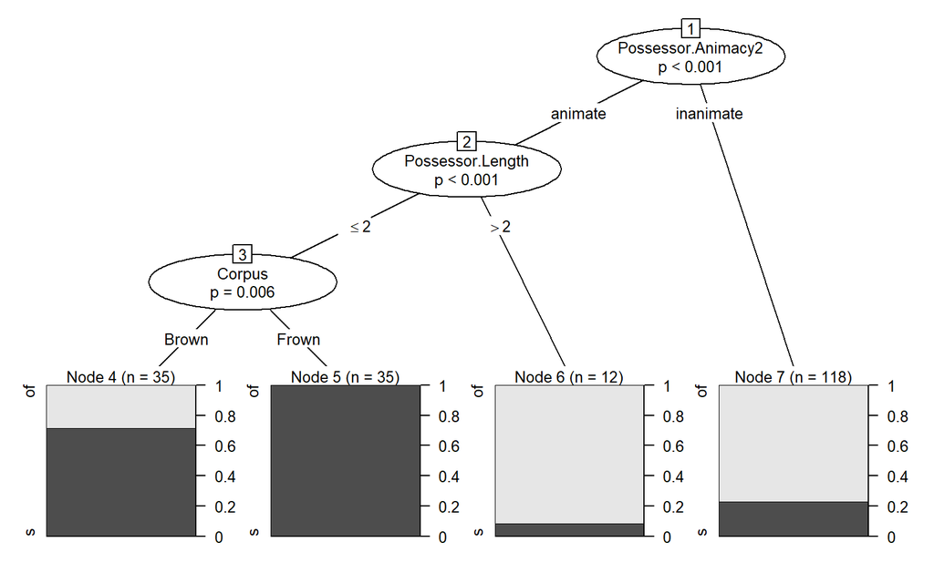

Tree Sample 1

```r
set.seed(12345)
partykit::ctree(gen_fmla2,
  data = gens[sample(1:nrow(gens), 200, replace = F), ],
  control = partykit::ctree_control(mincriterion = .99, maxdepth = 4)
) %>%
  plot(gp = gpar(cex = .8))
```

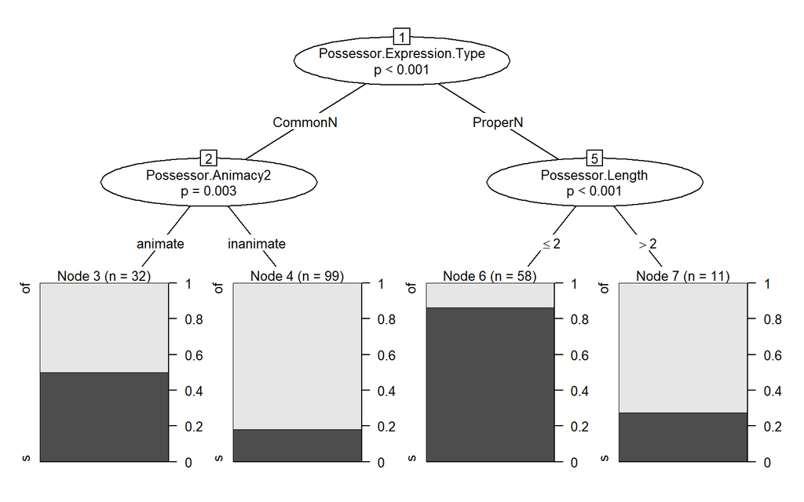

Tree Sample 2

```r
partykit::ctree(gen_fmla2,
  data = gens[sample(1:nrow(gens), 200, replace = F), ],
  control = partykit::ctree_control(mincriterion = .99, maxdepth = 4)
) %>%
  plot(gp = gpar(cex = .8))
```

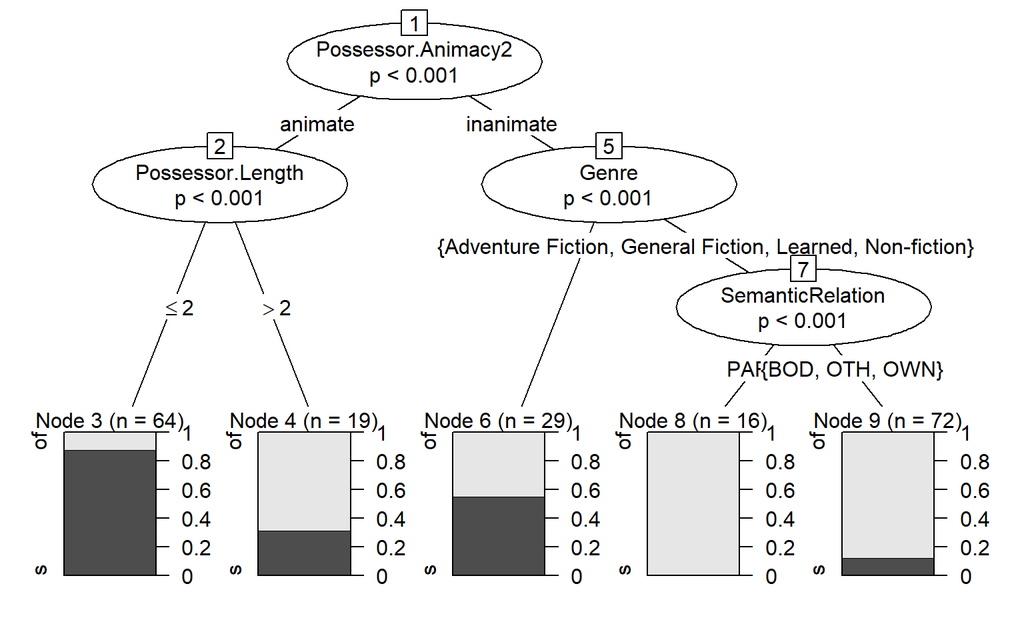

Tree Sample 3

```r
ctree(gen_fmla2,
  data = gens[sample(1:nrow(gens), 200, replace = F), ],
  control = ctree_control(mincriterion = .99, maxdepth = 4)
) %>%
  plot(gp = gpar(cex = .8))
```

Now, these are small datasets (N = 200), and with larger samples we would likely get more convergence among the trees (try it yourself!). But the larger point is that tree structures are highly volatile and sensitive to the particulars of the datasets they are trained on.

Random forests are one way of getting around this problem. They are one of a family of techniques that use **ensemble methods** to generate predictions. These methods rely on aggregating and summarising over lots of models rather than relying on one single model to derive predictions.

In the next couple sections I’ll go over some other key aspects of random forests.

## Bagging

One aspect of the random forests involves a process known as **Bootstrap Aggregating**, or **bagging**. [(wikipedia)](https://en.wikipedia.org/wiki/Bootstrap_aggregating) Bagging is a technique used to reduce the variance of our predictions from individual trees by combining the result of many hundreds or thousands of trees trained on different sub-samples of the dataset. In this way, bagging is designed to improve the reliability and accuracy of a model as well as reduce variance and potential overfitting.

To obtain subsamples of the data, bagging relies on the principle of random sampling with replacement, or **bootstrapping**. The basic idea of bootstrapping goes as follows. Given a data set $D_1$ with $n$ observations, we create a new dataset $D_2$ by randomly pulling out $n$ observations from the original dataset $D_1$, allowing that some of those observations may be copies. This is known as sampling “with replacement,” which simply means that each time we take a sample item from our set, we “replace” it with a copy in the original dataset. So the pool from which we draw our samples always stays the same, meaning that we could draw that same item again.

To illustrate, we can create a boostrap sample of 26 letters from the English alphabet. R has a built in vector `letters` that we’ll use as our original “dataset.”

```r
letters
```

```
 [1] "a" "b" "c" "d" "e" "f" "g" "h" "i" "j" "k" "l" "m" "n" "o" "p" "q" "r" "s"
[20] "t" "u" "v" "w" "x" "y" "z"
```

We create a new dataset by selecting a letter at random 26 times. This is our **bootstrap sample**.

```r
D2 <- sample(letters, replace = T)
sort(D2)
```

```
 [1] "a" "b" "c" "c" "d" "i" "i" "k" "l" "l" "l" "m" "m" "n" "n" "n" "o" "o" "s"
[20] "t" "v" "w" "w" "w" "w" "y"
```

We can see that some observations (letters) are repeated, and some others are not included at all. This is the effect of sampling with replacement. We can see the proportion of non-repeated items…

```r
# your mileage may vary
length(unique(D2)) / length(D2)
```

```
[1] 0.5769231
```

Usually, about 1/3 of the observations from D1 are left out of D2. This is typical no matter how large the original dataset is.

One thing it’s important to remember is that because we’re moving into methods that rely on (pseudo-)randomness, our results may vary across runs. This is why it’s important to set the **random seed** prior to running our models so that we can replicate our results again. Almost all computer programs [use algorithms to simulate randomness](https://www.freecodecamp.org/news/random-number-generator/), and [R is no different](https://stats.stackexchange.com/questions/65928/how-exactly-does-the-r-random-number-generator-work). We can take advantage of this fact to make sure we get the same results every time we run a (pseudo) random process. We do this by setting the initial state of the random number generator to a predefined value with `set.seed()`.

```r
set.seed(43214)
```

Which value you choose doesn’t matter, but starting at that seed will always produce the same results.

Make sure to set this, and track it in your code so that you and anyone else can reproduce your analysis.

## Random predictor sampling

A second aspect of random forests that makes them different from standard bagging methods is that when growing the individual trees, the method adds a second element of randomness in the selection of predictors that are included in each tree. When we have *k* input predictors, the random forest will randomly select a subset *m* < *k* out of the *k* predictors at each node, in each tree. The best split on these *m* predictors is used to split the node.

To sum up, instead of using a single tree, Random Forests grow many many trees (a ‘forest’), each of which is grown on random subsamples of the data using randomly selected subsets of predictors. This results in a healthy mix of very diverse trees, which compensates for sparse values in the data while at the same time giving full consideration to possible effects of all predictors. This is one of the major advantages of this method.

# Random forests in R

## Libraries

There are two packages I use for working with random forests: the `{ranger}` package and the `{party}` package, which is a progenitor of `{partykit}`. You may also come across the `{randomForest}` package, which is an older package that uses the same methods as `{ranger}`, however it runs a bit slower and has been largely replaced by `{ranger}` now. As usual, I’m also working with [tidyverse](https://www.tidyverse.org/) functions for data wrangling and plotting.

Let’s load our libraries.

```r
# install and load
library(tidyverse)
library(patchwork)
# for random forests
library(ranger)
library(party)
```

## Datasets for this tutorial

For for classification trees we’ll use some of the datasets we looked at before.

```r
# English genitives ('s vs. of)
gens <- read_delim(
  "https://raw.githubusercontent.com/jasongraf1/Bham_Stats_Summer_School_2022/main/data/brown_genitives.txt",
  delim = "\t",
  trim_ws = TRUE,
  col_types = cols()
  )
# English relativizers (that vs. which vs. ZERO)
rels <- read_delim(
  "https://raw.githubusercontent.com/jasongraf1/Bham_Stats_Summer_School_2022/main/data/brown_relativizers.txt",
  delim = "\t",
  trim_ws = TRUE,
  col_types = cols()
  )
# English lexical decision response times
english <- languageR::english %>%
  as_tibble()
```

## Fitting the models

### Setting hyperparameters

Before starting, we need to specify two important **hyperparameters** for our models. Simply, hyperparameters are parameters used to control the model learning process (wikipedia). In random forests, the two most commonly discussed parameters are:

- The number of input predictors randomly selected at each node of a given tree in the forest. We’ll call this $m$
- The total number of trees to grow in the forest. We’ll call this $N_{tree}$

Both of these can have potentially substantial impact on your model. As a rule of thumb, Breiman (2001) recommends setting $m$ equal to $\sqrt{k}$ for a model with $k$ predictors, and this is good for a first pass. The number of trees is something that is a bit harder to determine. Generally speaking, the smaller your dataset, and/or the larger the number of predictors, the more trees you should grow. Again, there are methods for exploring just what the optimal setting might be, but these can be very time consuming. These optimization methods are arguably less than ideal for inference, as they are yet another dimension where potential researcher bias can creep in (OTOH, optimization techniques are very good for computational applications which care only about prediction accuracy). That said, there are methods for choosing trees in relatively unbiased ways (see Oshiro, Perez & Baranauskas 2012). Anyway, the number of trees and number of predictors are the two key parameters that all RF methods require us to stipulate beforehand.

There are other hyperparameters, and we’ll see methods for determining empirically what the optimal settings should be (a process known as “tuning”) in a later tutorial.

### Formulas

Again we’ll use the same formulas as in the CART tutorial.

```r
gen_fmla2 <- Type ~ Possessor.Animacy2 + Final.Sibilant +
  Possessor.Length + SemanticRelation + Possessor.Expression.Type +
  Genre + Corpus + Possessum.Length + PossessorThematicity

# convert categorical columns to factors
gens <- gens %>%
  mutate(across(all.vars(gen_fmla2)[c(1:3, 5:8)], as.factor))
```

### `{ranger}` package

First let’s fit a forest with the `{ranger}` package. Like `rpart` this uses by default the Gini impurity measure for splitting trees.

We’ll set the number of trees to grow at 1000, and set *m* to 3. We’ll also include the argument `importance = "impurity"`, which will tell the model to provide a relative measure of how much each individual predictor adds to the predictive accuracy of the model. This will add to the computation time, but is valuable information to know. We’ll come back to this below.

```r
# impurity (Gini impurity)
system.time(
  gen_ranger_gini <- ranger(gen_fmla2,
    data = gens,
    seed = 1234, # set the random seed
    num.trees = 1000,
    mtry = 3,
    importance = "impurity" #
  )
)
```

```
   user  system elapsed
   4.03    0.09    1.91
```

A great thing about `{ranger}` is that it is very fast!

Let’s check the output.

```r
gen_ranger_gini
```

```
Ranger result

Call:
 ranger(gen_fmla2, data = gens, seed = 1234, num.trees = 1000,      mtry = 3, importance = "impurity")

Type:                             Classification
Number of trees:                  1000
Sample size:                      5098
Number of independent variables:  9
Mtry:                             3
Target node size:                 1
Variable importance mode:         impurity
Splitrule:                        gini
OOB prediction error:             10.08 %
```

The printout tells us a number of things. It gives us the hyperparameter settings (`Target node size` refers to the minimum number of observations allowed in a node), along with the number of observations (`Sample size`), the variable importance measure, and the splitting method.

It also gives an estimate of accuracy based on the **out-of-bag** (OOB) error rates. “Out-of-bag” refers to those observations that are left out of the randomly sampled “bag” of data used to train each tree. For each tree, we test its predictions on these OOB observations and derive an error rate. This gives us a measure of how accurate the tree is at predicting the outcome for data that *it has never seen before*. Using OOB accuracy is a way to safeguard against building a model that is too finely tuned to the specific dataset, i.e. a model that overfits the data.

The average error over all the trees is the estimated prediction error for the forest as a whole. In other words, the predictive accuracy is 1 - the OOB error rate.

We can obtain predictions directly with `gen_ranger_gini$predictions`, or with the `predict()` function, and measure the accuracy based on this. We just count the cases where the model prediction matches the observed variant, and divide by the total number of observatiosn

```r
sum(gen_ranger_gini$predictions == gens$Type)/nrow(gens)
```

```
[1] 0.8991761
```

#### Probability forests

Normally `{ranger}` fits classification forests whose predictions are discrete class labels.

```r
head(gen_ranger_gini$predictions)
```

```
[1] of of s  of s  s
Levels: of s
```

But if we want to generate predicted *probabilities* of the classes we can do that by setting the `probability = TRUE` argument.

```r
gen_ranger_prob <- ranger(
  gen_fmla2,
  data = gens,
  seed = 1234, # set the random seed
  num.trees = 1000,
  mtry = 3,
  importance = "impurity",
  probability = TRUE
  )

head(gen_ranger_prob$predictions)
```

```
            of          s
[1,] 0.9264538 0.07354620
[2,] 0.9245828 0.07541723
[3,] 0.4339831 0.56601694
[4,] 0.9157525 0.08424754
[5,] 0.0179418 0.98205820
[6,] 0.4517868 0.54821324
```

So here we have a dataframe containing predicted probabilities for each possible outcome. With these we can calculate, among other things, the concordance index *C*, which is a better measure of model performance for binary outcomes than the prediction accuracy (Harrell 2015:257).

```r
Hmisc::somers2(gen_ranger_prob$predictions[,2], as.numeric(gens$Type) - 1)
```

```
           C          Dxy            n      Missing
   0.9588273    0.9176546 5098.0000000    0.0000000
```

Note that this value of *C* is effectively the same as the Area under the ROC curve (AUC).

### `{party}` package

Next we’ll try random forests with the `{party}` package (random forests have not been fully implemented in `{partykit}`). For this package we use the `cforest()` function. First we should make sure to detach `{partykit}` and load `{party}`. This is important to avoid conflicts between the two packages which share many of the same functions. `{party}` relies on conditional inference trees similar to those in `{partykit}`.

```r
detach("package:partykit", unload = TRUE)
library(party)
```

For `{party}`, we need to set the hyperparameters inside the `cforest_control()` function. Once we’ve set our hyperparameters, we can fit our tree with `cforest()`. We will start with a simpler model, because this method is *much* slower than `{ranger}`.

```r
ctrl <- cforest_control(mtry = 3, ntree = 1000) # same settings as above

set.seed(1234)
system.time(
  gen_party1 <- party::cforest(
    Type ~ Possessor.Animacy2 + Final.Sibilant +
    Possessor.Length + Genre + Corpus,
  data = gens,
  controls = ctrl
  )
)
```

```
   user  system elapsed
  37.12    0.16   39.37
```

The output of the `cforest()` function is annoyingly not very informative.

```r
print(gen_party1)
```

```
     Random Forest using Conditional Inference Trees

Number of trees:  1000

Response:  Type
Inputs:  Possessor.Animacy2, Final.Sibilant, Possessor.Length, Genre, Corpus
Number of observations:  5098
```

Note also that random forests, especially `{party}` forests are *very* large objects (at least > 100Mb) so they can be slow to load and can bog down your system.

We can get the predictions from the model like so, though again this may take some time (about 10 minutes on my laptop).

```r
system.time(
  gen_party1_preds <- predict(gen_party1, newdata = gens, type = "prob")
)
```

```
   user  system elapsed
 549.02    0.25  551.38
```

```r
head(gen_party1_preds)
```

```
$`1`
       Type.of    Type.s
[1,] 0.6534872 0.3465128

$`2`
       Type.of     Type.s
[1,] 0.9055353 0.09446466

$`3`
       Type.of    Type.s
[1,] 0.2678139 0.7321861

$`4`
       Type.of    Type.s
[1,] 0.6534872 0.3465128

$`5`
       Type.of    Type.s
[1,] 0.2678139 0.7321861

$`6`
       Type.of    Type.s
[1,] 0.2678139 0.7321861
```

The output is a list, so we have to loop through and get the predicted *s*-genitive probabilities.

```r
gen_preds1 <- map_dbl(gen_party1_preds, .f = function(x) return(x[2]))
Hmisc::somers2(gen_preds1, as.numeric(gens$Type) - 1)
```

```
           C          Dxy            n      Missing
   0.9069586    0.8139172 5098.0000000    0.0000000
```

So our model is not as good as the `{ranger}` model, but note that we didn’t include all the predictors in this model to cut down on processing time.

# Predictor importance

Unlike single trees or regression models, interpreting a random forest model is not easy because a single predictor can show up in many different (non-nested) trees with different co-varying predictors (and interactions). So random forests don’t give you direct effect size measures comparable to regression coefficients.

However, random forests and ensemble methods make up for this shortcoming in being a great tool for evaluating the relative predictive importance of individual predictors. Due to the random (sub)sampling and bagging processes, they are often very good at determining the independent contributions of individual predictors to the model even when those predictors are highly correlated with one another. And since they rely on many, many trees, they can model non-linearities and complex ‘interactions’ quite naturally (though this should perhaps be treated with some caution, see Gries 2019).

To assess the contribution of each predictor, the random forest models compute a **predictor importance** score (also called “variable importance” or “feature importance”). That’s what the `importance` arguments were for in the functions above.

## `{ranger}`

The `{ranger}` package allows us to use several importance measures. It’s generally recommended to use permutation-based methods, as permutation methods have been shown to be less biased than other measures (Strobl, Malley & Tutz 2009; Altmann et al. 2010). Permutation variable importance works fairly straightforwardly:

> To evaluate predictor importance, a tree is grown in the first step, and the prediction accuracy in the OOB observations is calculated. In the second step, any association between the variable of interest *x<sub>i</sub>* and the outcome is broken by permuting the values of all individuals for *x<sub>i</sub>*, and the prediction accuracy is computed again. The difference between the two accuracy values is the permutation importance for *x<sub>i</sub>* from a single tree. The average of all tree importance values in a random forest then gives the random forest permutation importance of this variable. The procedure is repeated for all [predictors] of interest. (Wright, Ziegler & König 2016:3)

In other words, we…

1. Grow a tree predicting a response from a set of predictors.
2. Take one predictor and randomly shuffle the values of that predictor. This breaks the association between the response and that predictor
3. Calculate the difference in model accuracy before and after shuffling the predictor
4. Repeat for all trees and all predictors in the forest

The reasoning is as follows. If the predictor does not have a meaningful relationship with the response, shuffling its values should produce very little change in model accuracy. On the other hand, if the predictor was strongly associated with the response, permutation should create a large drop in accuracy. We do this for every predictor in the model, and rank them according to their importance.

Permutation based importance measures can be obtained for `{ranger}` models easily.

```r
gen_ranger_perm <- ranger(gen_fmla2,
    data = gens,
    seed = 1234, # set the random seed
    num.trees = 1000,
    mtry = 3,
    importance = "permutation"
  )
```

The values can be obtained with the `importance()` wrapper function, or you can get them directly with `gen_ranger_perm$variable.importance`

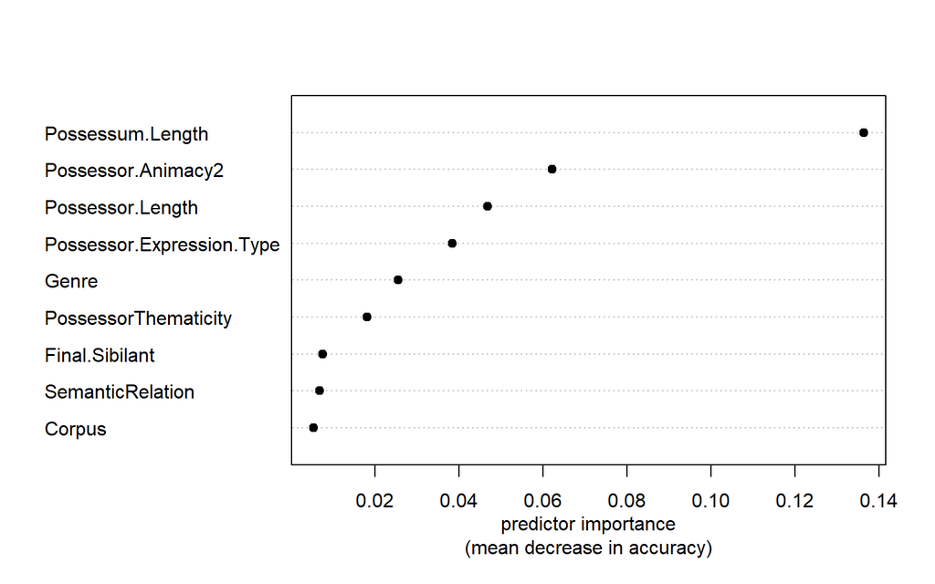

```r
importance(gen_ranger_perm) %>%
  sort() %>%
  dotchart(
    pch = 19,
    xlab = "predictor importance\n(mean decrease in accuracy)")
```

A nice thing about `{ranger}` is that we can calculate significance tests for which predictors are important, following methods of Janitza, Celik & Boulesteix (2016) and Altmann et al. (2010). The first method is faster, but requires there to be a negative value (see below). The second method takes some time to compute…

```r
system.time(
  gen_ranger_varimp.pvals <- importance_pvalues(
    gen_ranger_perm,
    formula = gen_fmla2,
    data = gens,
    method = "altmann"
  ))
```

```
   user  system elapsed
1048.32    8.99  317.24
```

Now, while the `dotchart()` is simple, I’ll use use a `{ggplot}` method to color the dots by significance (red = significant).

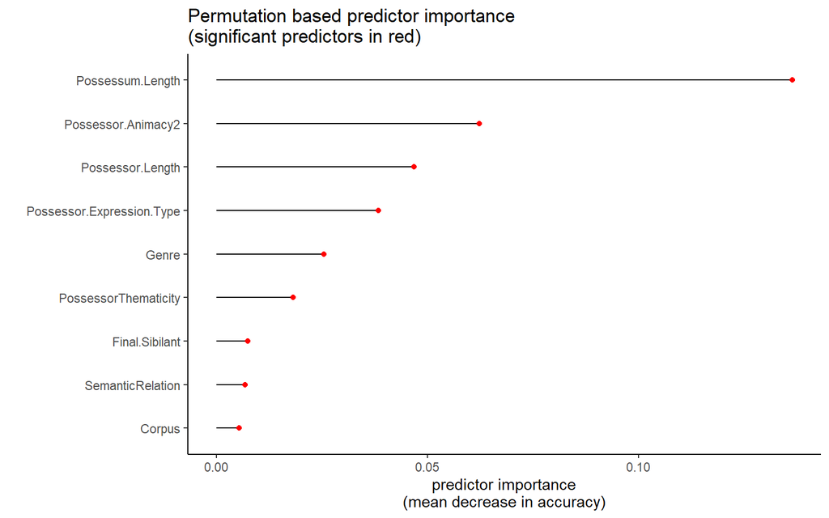

```r
gen_ranger_varimp.pvals %>%
  as.data.frame() %>%
  mutate(
    pred = factor(rownames(.)),
    sig = if_else(pvalue > .05, "sig", "nonsig")
  ) %>%
  ggplot(aes(fct_reorder(pred, importance), importance)) +
  geom_segment(aes(xend = pred, yend = 0)) +
  geom_point(aes(color = sig)) +
  scale_color_manual(
    guide = "none",
    values = c("red", "grey")) + # non-sig predictors will be grey
  labs(
    x = "",
    y = "predictor importance\n(mean decrease in accuracy)",
    title = "Permutation based predictor importance\n(significant predictors in red)"
  ) +
  coord_flip()
```

In this case, we can see that all the predictors make a significant contribution. But some are clearly more important than others, as noted by the large drop in accuracy.

## `{party}`

The `{party}` package uses permutation importance measures as well, and it offers two measures, the decrease in prediction accuracy (`varimp()`) and the decrease in the concordance statistic *C*, or AUC (`varimpAUC()`). Again, the latter has been shown to be a more reliable measure (Janitza, Strobl & Boulesteix 2013), so we’ll use that.

The only drawback is that these are both also very time consuming (like everything in `{party}`…). So we’ll use the `{permimp}` package which was designed to be much faster, though still not as fast as `{ranger}`.

```r
library(permimp)
# track the time it takes to run
system.time(
  gen_party1_varimp <- permimp(
    gen_party1,
    AUC = TRUE,
    progressBar = FALSE
    ))
```

```
   user  system elapsed
  61.65    0.08   62.89
```

Once we have our variable importance object, we can plot the results. First we convert it to a data.frame object.

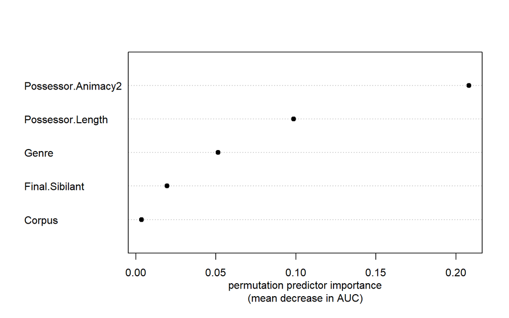

```r
# Subtract 1 due to some issues with negative values...
gen_party1_varimp$values %>%
  sort() %>%
  dotchart(
    pch = 19,
    xlab = "permutation predictor importance\n(mean decrease in AUC)"
  )
```

A ggplot version:

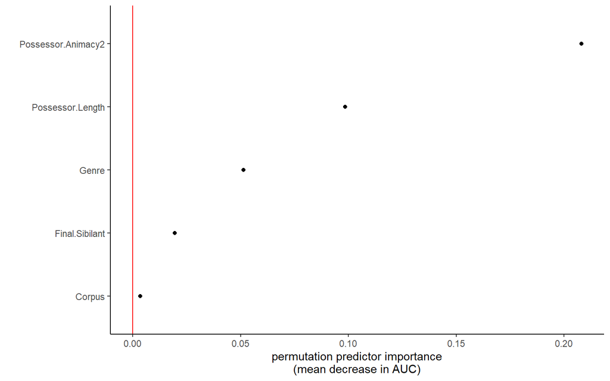

```r
gen_party1_varimp$values %>%
  as.data.frame() %>%
  rename(varimp = ".") %>%
  mutate(pred = rownames(.) %>% factor()) %>%
  ggplot(aes(fct_reorder(pred, varimp), varimp)) +
  geom_point() +
  labs(x = "", y = "permutation predictor importance\n(mean decrease in AUC)") +
  geom_hline(yintercept = 0, color = "red") +
  coord_flip()
```

By chance, the random reordering of values sometimes results in a configuration that affords a slightly *better* model. This may arise when the values of an irrelevant predictor are reshuffled. In other words, the random reshuffling created a new version of the predictor that is actually *more* strongly associated with the outcome than the original predictor. This has the effect of creating a negative variable importance score.

By mirroring the minimal score to the right of zero, we obtain an interval that characterizes irrelevant predictors. Variables can be considered informative and important if their variable importance value lies above (to the right) this region (Strobl, Malley & Tutz 2009; Janitza, Celik & Boulesteix 2016). In some cases, this may include all predictors.

It’s important to remember that these variable importance scores should only be interpreted relative to each other as a ranking of the model’s predictors. The absolute values of the scores should not be interpreted or compared across studies (see Strobl et al. 2008:336).

Since the forest are random, they should also be verified by fitting multiple models with different random seeds and ntree numbers.

### Conditional variable importance

Multicollinearity is a known problem for many naturalistic datasets. There are often many predictors that are correlated with one another to varying degrees. The `party` package offers a method for dealing with this by using *conditional* variable importance measures (Strobl et al. 2008). From `help(varimp)`:

> If `conditional = TRUE`, the importance of each variable is computed by permuting within a grid defined by the covariates that are associated (with 1 - p-value greater than threshold) to the variable of interest.

This can be calculated as follows, however, be warned this can take a **very** long time.

```r
# track the time it takes to run
system.time(
  gen_party1_varimp_cond <- permimp(
    gen_party1,
    AUC = TRUE,
    progressBar = FALSE,
    conditional = TRUE
    ))
```

```
   user  system elapsed
 137.00    0.11  139.78
```

We can compare the unconditional and conditional importances, and see in this case there is relatively little difference.

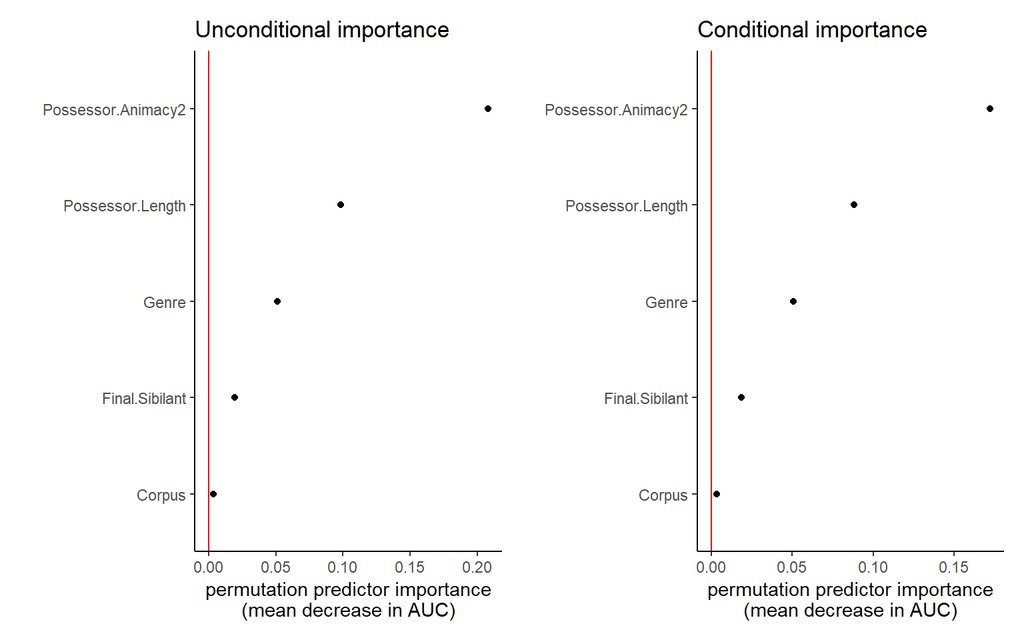

```r
p1 <- gen_party1_varimp$values %>%
  as.data.frame() %>%
  rename(varimp = ".") %>%
  mutate(pred = rownames(.) %>% factor()) %>%
  ggplot(aes(fct_reorder(pred, varimp), varimp)) +
  geom_point() +
  labs(x = "", y = "permutation predictor importance\n(mean decrease in AUC)") +
  ggtitle("Unconditional importance") +
  geom_hline(yintercept = 0, color = "red") +
  coord_flip()
p2 <- gen_party1_varimp_cond$values %>%
  as.data.frame() %>%
  rename(varimp = ".") %>%
  mutate(pred = rownames(.) %>% factor()) %>%
  ggplot(aes(fct_reorder(pred, varimp), varimp)) +
  geom_point() +
  labs(x = "", y = "permutation predictor importance\n(mean decrease in AUC)") +
    ggtitle("Conditional importance") +
  geom_hline(yintercept = 0, color = "red") +
  coord_flip()

p1 + p2
```

# What about mixed-effects random forests?

Adapting random forest methods to handle multi-level datasets, like when observations are clustered by speakers in an experiment or text files in a corpus, is currentlt a very active area of research. Unfortunately however, the methods available are not easy to implement in R. There is a relatively easy-to-use implementation of mixed-effects random forests (MERFs) in Python available https://pypi.org/project/merf/, but this only works for continuous response variables (Hajjem, Bellavance & Larocque 2014). More about this can be found [here](https://towardsdatascience.com/mixed-effects-random-forests-6ecbb85cb177).

Other methods for categorical responses are in development, e.g. Speiser et al. (2018), but nothing has been implemented in R yet.

# Summary

**Advantages of random forests:**

- **Small n, big p**: Random forests can handle small datasets with relatively large sets of predictors. This is a problem for other methods
- **Very accurate**: Random forests are typically much more accurate than single trees and even regression models
- Random forests are also generally less sensitive to problems of collinearity due to their bagging and random variable selection procedures, however proper care should still be taken (e.g. using conditional variable importance measures)
- Random forests deal well with nonlinear effects and high-order interactions (though care should be taken, see Gries 2019; Wright, Ziegler & König 2016)

**Disadvantages of random forests:**

- They cannot handle non-independence well. They don’t have a way of incorporating hierarchical data structures, i.e.”random” effects for speaker, text, etc.
- They have potentially long computing time (especially for variable importance)
- They do not provide traditional measures of effect size, direction, or significance, and exploring “interaction effects” is not always straightforward (Gries 2019). I disucss how to deal with these issues in another tutorial.

# References

Altmann, André, Laura Toloşi, Oliver Sander & Thomas Lengauer. 2010. Permutation importance: A corrected feature importance measure. *Bioinformatics* 26(10). 1340–1347. doi:cm7h6d.

Breiman, Leo. 2001. Random Forests. *Machine Learning* 41. 5–32.

Gries, Stefan Th. 2019. On classification trees and random forests in corpus linguistics: Some words of caution and suggestions for improvement. *Corpus Linguistics and Linguistic Theory* 0(0). doi:10.1515/cllt-2018-0078.

Hajjem, Ahlem, François Bellavance & Denis Larocque. 2014. Mixed-effects random forest for clustered data. *Journal of Statistical Computation and Simulation* 84(6). 1313–1328. doi:10.1080/00949655.2012.741599.

Harrell, Frank E. 2015. *Regression Modeling Strategies*. Second. New York: Springer.

Janitza, Silke, Ender Celik & Anne-Laure Boulesteix. 2016. A computationally fast variable importance test for random forests for high-dimensional data. *Advances in Data Analysis and Classification*. doi:gdj8zn.

Janitza, Silke, Carolin Strobl & Anne-Laure Boulesteix. 2013. An AUC-based permutation variable importance measure for random forests. *BMC Bioinformatics* 14(1). 119. doi:f4s4cx.

Oshiro, Thais Mayumi, Pedro Santoro Perez & José Augusto Baranauskas. 2012. How many trees in a Random Forest? In David Hutchison, Takeo Kanade, Josef Kittler, Jon M. Kleinberg, Friedemann Mattern, John C. Mitchell, Moni Naor, et al. (eds.), *Machine Learning and Data Mining in Pattern Recognition*, vol. 7376, 154–168. Berlin, Heidelberg: Springer Berlin Heidelberg. doi:10.1007/978-3-642-31537-4_13.

Speiser, Jaime Lynn, Bethany J. Wolf, Dongjun Chung, Constantine J. Karvellas, David G. Koch & Valerie L. Durkalski. 2018. BiMM tree: A decision tree method for modeling clustered and longitudinal binary outcomes. *Communications in Statistics - Simulation and Computation* 0(0). 1–20. doi:10.1080/03610918.2018.1490429.

Strobl, Carolin, Anne-Laure Boulesteix, Thomas Kneib, Thomas Augustin & Achim Zeileis. 2008. Conditional variable importance for random forests. *BMC Bioinformatics* 9(1). 307. doi:10.1186/1471-2105-9-307.

Strobl, Carolin, James Malley & Gerhard Tutz. 2009. An introduction to recursive partitioning: Rationale, application, and characteristics of classification and regression trees, bagging, and random forests. *Psychological Methods* 14(4). 323–348. doi:10.1037/a0016973.

Wright, Marvin N., Andreas Ziegler & Inke R. König. 2016. Do little interactions get lost in dark random forests? *BMC Bioinformatics* 17(1). doi:b5t7.